# Week 9 - Group Submission - R

## Summary

These four data sets are together known as Anscombe’s Quartet, developed in 1973 by professor Francis Anscombe. With nearly identical means, sample variances, correlation coefficients and linear regression lines, these data sets demonstrate the significance of graphically visualizing data, as well as the potentially large influence on the data of one or two significant outliers. Using R and Python code, our team was able to analyze both the similarities and differences of the data sets in this quartet. The primary takeaway of this exercise is the idea that representing data graphically is at least as significant as running layers of strictly quantitative analysis.

## Workspace

Below is consolidated code from the team

**Import Data**

```r
# from github cuny9.csv file
library(bitops)
library(RCurl)

options(RCurlOptions = list(cainfo = system.file("CurlSSL", "cacert.pem", package = "RCurl")))
fileurl= "https://raw.githubusercontent.com/DataProgrammingBridge2014/RCodeDevelopment/master/cuny9.csv"
data <- getURL(fileurl)
cuny9 <- read.csv(text = data)

# split data into data sets
Idf <- data.frame(x = cuny9$x1, y = cuny9$y1)
IIdf <- data.frame(x = cuny9$x2, y = cuny9$y2)
IIIdf <- data.frame(x = cuny9$x3, y = cuny9$y3)
IVdf <- data.frame(x = cuny9$x4, y = cuny9$y4)
```

**Initial plots**

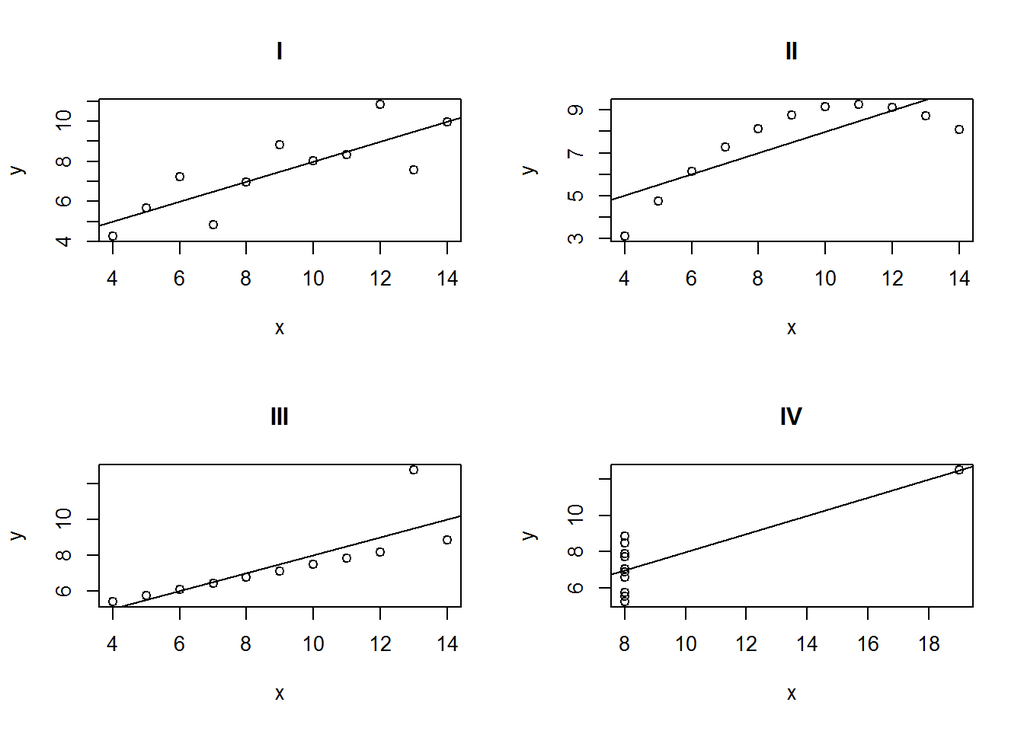

```r
par(mfrow=c(2,2))
plot(Idf, main="I")
abline(lm(Idf$y ~ Idf$x))
plot(IIdf, main="II")
abline(lm(IIdf$y ~ IIdf$x))
plot(IIIdf, main="III")
abline(lm(IIIdf$y ~ IIIdf$x))
plot(IVdf, main="IV")
abline(lm(IVdf$y ~ IVdf$x))
```

We can see that all four have a very similar regression line, but obviously those regression lines don’t tell us very much about II, III, or IV.

**Summaries of Data Sets**

```r
summary(Idf)
```

```
##        x              y
##  Min.   : 4.0   Min.   : 4.26
##  1st Qu.: 6.5   1st Qu.: 6.32
##  Median : 9.0   Median : 7.58
##  Mean   : 9.0   Mean   : 7.50
##  3rd Qu.:11.5   3rd Qu.: 8.57
##  Max.   :14.0   Max.   :10.84
```

```r
summary(IIdf)
```

```
##        x              y
##  Min.   : 4.0   Min.   :3.10
##  1st Qu.: 6.5   1st Qu.:6.70
##  Median : 9.0   Median :8.14
##  Mean   : 9.0   Mean   :7.50
##  3rd Qu.:11.5   3rd Qu.:8.95
##  Max.   :14.0   Max.   :9.26
```

```r
summary(IIIdf)
```

```
##        x              y
##  Min.   : 4.0   Min.   : 5.39
##  1st Qu.: 6.5   1st Qu.: 6.25
##  Median : 9.0   Median : 7.11
##  Mean   : 9.0   Mean   : 7.50
##  3rd Qu.:11.5   3rd Qu.: 7.98
##  Max.   :14.0   Max.   :12.74
```

```r
summary(IVdf)
```

```
##        x            y
##  Min.   : 8   Min.   : 5.25
##  1st Qu.: 8   1st Qu.: 6.17
##  Median : 8   Median : 7.04
##  Mean   : 9   Mean   : 7.50
##  3rd Qu.: 8   3rd Qu.: 8.19
##  Max.   :19   Max.   :12.50
```

**Basic Plots for Linear Model**

Shows Residuals vs. Fitted values, Theoretical Quantiles, Scale-Location, and Residuals vs. Leverage for a linear model for each data set I-IV

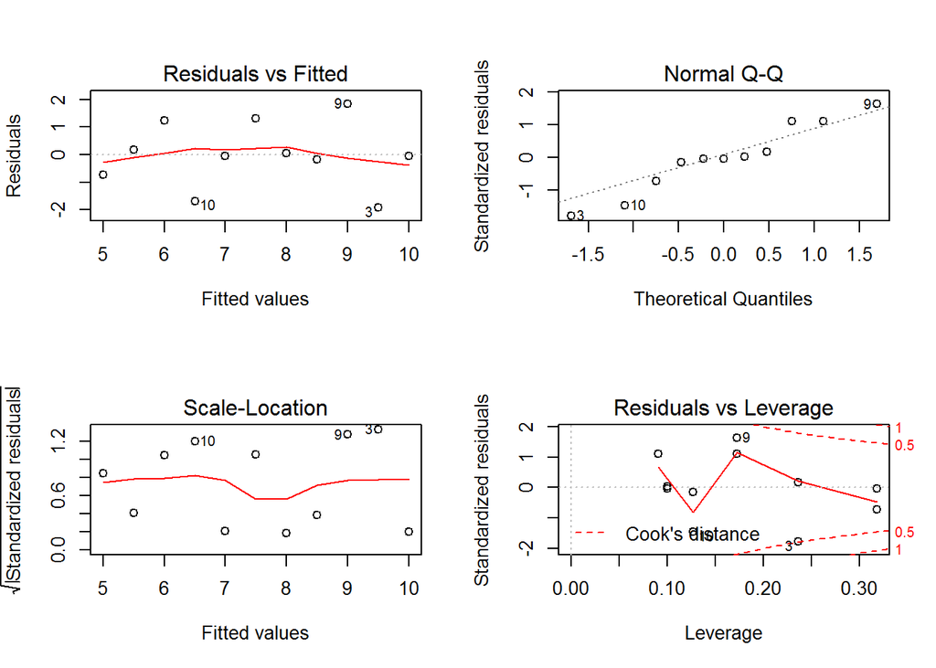

```r
#Now let's make a more accurate predition model: (each lm makes 4 pictures)
par(mfrow=c(2,2))
Ilm <- lm(formula = y ~ x, data = Idf)
plot(Ilm)
```

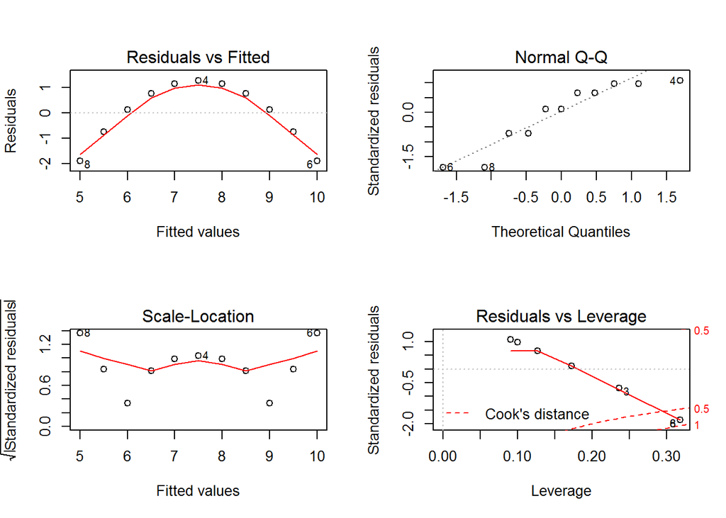

```r
#II
IIlm <- lm(formula = y ~ x, data = IIdf)
plot(IIlm)
```

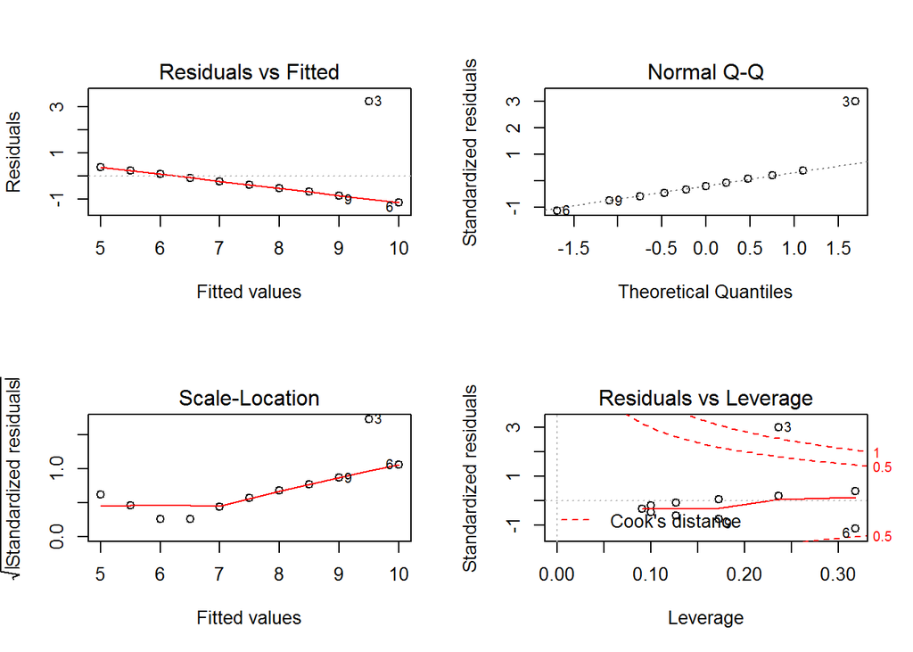

```r
#III
IIIlm <- lm(formula = y ~ x, data = IIIdf)
plot(IIIlm)
```

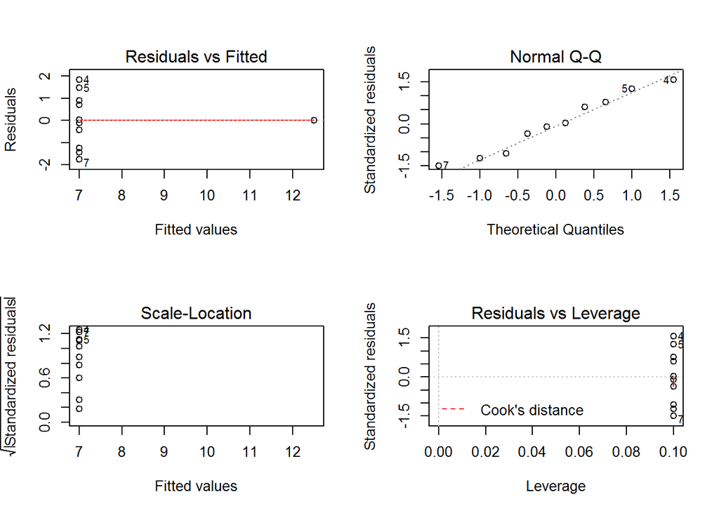

```r
#IV
IVlm <- lm(formula = y ~ x, data = IVdf)
plot(IVlm)
```

**Correlation and Plots Using ggplot2**

```r
library(ggplot2)
library(grid)
library(gridExtra)

cor(cuny9)
```

```
##          X      x1      y1      x2      y2      x3      y3      x4      y4
## X   1.0000 -0.4273 -0.3077 -0.4273 -0.5761 -0.4273 -0.4305  0.2000  0.1158
## x1 -0.4273  1.0000  0.8164  1.0000  0.8162  1.0000  0.8163 -0.5000 -0.3140
## y1 -0.3077  0.8164  1.0000  0.8164  0.7500  0.8164  0.4687 -0.5291 -0.4891
## x2 -0.4273  1.0000  0.8164  1.0000  0.8162  1.0000  0.8163 -0.5000 -0.3140
## y2 -0.5761  0.8162  0.7500  0.8162  1.0000  0.8162  0.5879 -0.7184 -0.4781
## x3 -0.4273  1.0000  0.8164  1.0000  0.8162  1.0000  0.8163 -0.5000 -0.3140
## y3 -0.4305  0.8163  0.4687  0.8163  0.5879  0.8163  1.0000 -0.3447 -0.1555
## x4  0.2000 -0.5000 -0.5291 -0.5000 -0.7184 -0.5000 -0.3447  1.0000  0.8165
## y4  0.1158 -0.3140 -0.4891 -0.3140 -0.4781 -0.3140 -0.1555  0.8165  1.0000
```

```r
plt1 <-ggplot(cuny9, aes(x=x1, y=y1)) + geom_point(shape=1) + geom_smooth(method=lm)+ggtitle("I")
plt2 <-ggplot(cuny9, aes(x=x2, y=y2)) + geom_point(shape=1) + geom_smooth(method=lm)+ggtitle("II")
plt3<-ggplot(cuny9, aes(x=x3, y=y3)) + geom_point(shape=1) + geom_smooth(method=lm)+ggtitle("III")
plt4<-ggplot(cuny9, aes(x=x4, y=y4)) + geom_point(shape=1) + geom_smooth(method=lm)+ggtitle("IV")
```

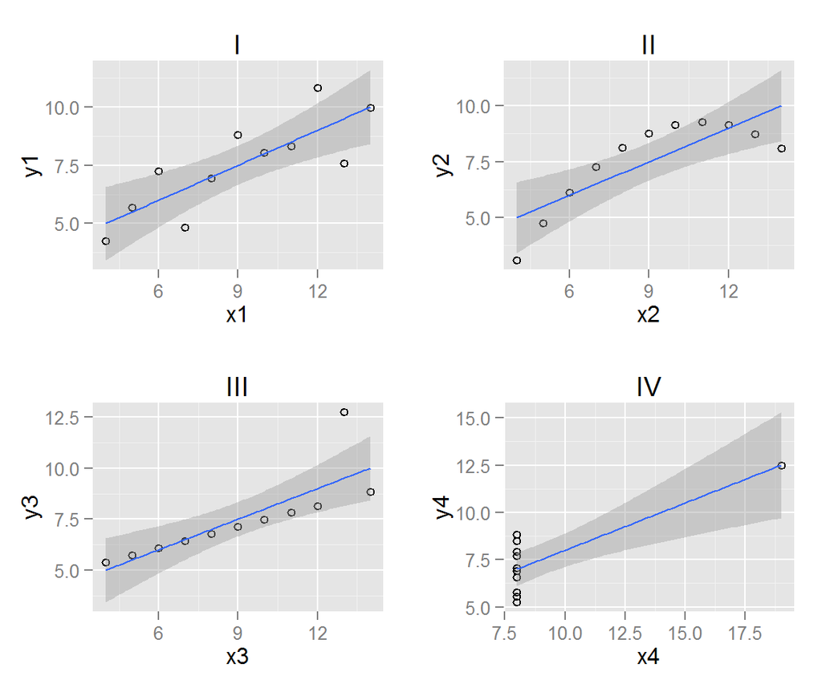

```r
grid.arrange(plt1,plt2,plt3,plt4)
```

```r
fit1 <- lm(y1 ~ x1, cuny9)
summary(fit1)
```

```
##
## Call:
## lm(formula = y1 ~ x1, data = cuny9)
##
## Residuals:
##     Min      1Q  Median      3Q     Max
## -1.9213 -0.4558 -0.0414  0.7094  1.8388
##
## Coefficients:
##             Estimate Std. Error t value Pr(>|t|)
## (Intercept)    3.000      1.125    2.67   0.0257 *
## x1             0.500      0.118    4.24   0.0022 **
## ---
## Signif. codes:  0 '***' 0.001 '**' 0.01 '*' 0.05 '.' 0.1 ' ' 1
##
## Residual standard error: 1.24 on 9 degrees of freedom
## Multiple R-squared:  0.667,  Adjusted R-squared:  0.629
## F-statistic:   18 on 1 and 9 DF,  p-value: 0.00217
```

```r
fit2 <- lm(y2 ~ x2, cuny9)
summary(fit2)
```

```
##
## Call:
## lm(formula = y2 ~ x2, data = cuny9)
##
## Residuals:
##    Min     1Q Median     3Q    Max
## -1.901 -0.761  0.129  0.949  1.269
##
## Coefficients:
##             Estimate Std. Error t value Pr(>|t|)
## (Intercept)    3.001      1.125    2.67   0.0258 *
## x2             0.500      0.118    4.24   0.0022 **
## ---
## Signif. codes:  0 '***' 0.001 '**' 0.01 '*' 0.05 '.' 0.1 ' ' 1
##
## Residual standard error: 1.24 on 9 degrees of freedom
## Multiple R-squared:  0.666,  Adjusted R-squared:  0.629
## F-statistic:   18 on 1 and 9 DF,  p-value: 0.00218
```

```r
fit3 <- lm(y3 ~ x3, cuny9)
summary(fit3)
```

```
##
## Call:
## lm(formula = y3 ~ x3, data = cuny9)
##
## Residuals:
##    Min     1Q Median     3Q    Max
## -1.159 -0.615 -0.230  0.154  3.241
##
## Coefficients:
##             Estimate Std. Error t value Pr(>|t|)
## (Intercept)    3.002      1.124    2.67   0.0256 *
## x3             0.500      0.118    4.24   0.0022 **
## ---
## Signif. codes:  0 '***' 0.001 '**' 0.01 '*' 0.05 '.' 0.1 ' ' 1
##
## Residual standard error: 1.24 on 9 degrees of freedom
## Multiple R-squared:  0.666,  Adjusted R-squared:  0.629
## F-statistic:   18 on 1 and 9 DF,  p-value: 0.00218
```

```r
fit4 <- lm(y4 ~ x4, cuny9)
summary(fit4)
```

```
##
## Call:
## lm(formula = y4 ~ x4, data = cuny9)
##
## Residuals:
##    Min     1Q Median     3Q    Max
## -1.751 -0.831  0.000  0.809  1.839
##
## Coefficients:
##             Estimate Std. Error t value Pr(>|t|)
## (Intercept)    3.002      1.124    2.67   0.0256 *
## x4             0.500      0.118    4.24   0.0022 **
## ---
## Signif. codes:  0 '***' 0.001 '**' 0.01 '*' 0.05 '.' 0.1 ' ' 1
##
## Residual standard error: 1.24 on 9 degrees of freedom
## Multiple R-squared:  0.667,  Adjusted R-squared:  0.63
## F-statistic:   18 on 1 and 9 DF,  p-value: 0.00216
```

**Coefficient Plots and Residuals**

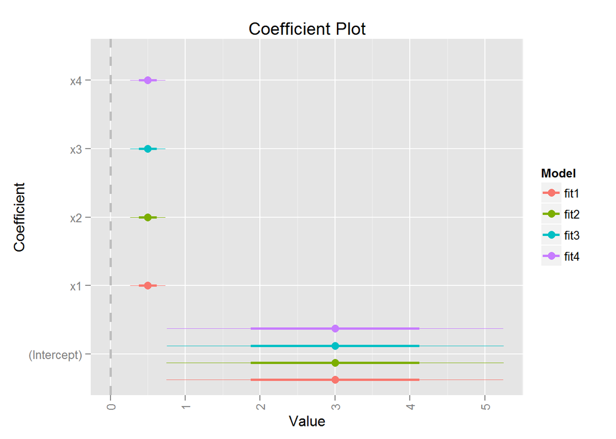

```r
library(coefplot)

multiplot(fit1, fit2, fit3, fit4)
```

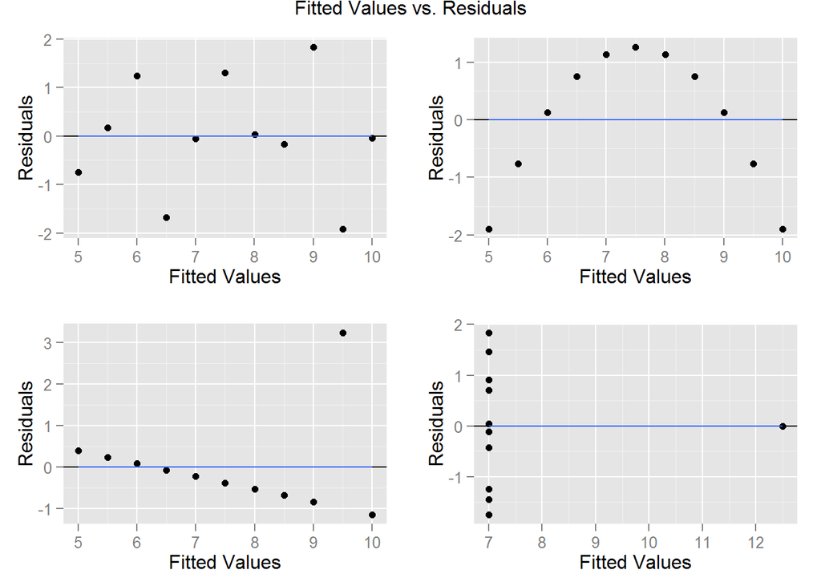

```r
#Fitted and residuals
plotfit1 <- ggplot(aes(x=.fitted, y=.resid), data=fit1)+geom_point()+geom_hline(yintercept=0)+geom_smooth(method = lm, se=F)+labs(x="Fitted Values", y="Residuals")
plotfit2 <- ggplot(aes(x=.fitted, y=.resid), data=fit2)+geom_point()+geom_hline(yintercept=0)+geom_smooth(method = lm, se=F)+labs(x="Fitted Values", y="Residuals")
plotfit3 <- ggplot(aes(x=.fitted, y=.resid), data=fit3)+geom_point()+geom_hline(yintercept=0)+geom_smooth(method = lm, se=F)+labs(x="Fitted Values", y="Residuals")
plotfit4 <- ggplot(aes(x=.fitted, y=.resid), data=fit4)+geom_point()+geom_hline(yintercept=0)+geom_smooth(method = lm, se=F)+labs(x="Fitted Values", y="Residuals")

suppressWarnings(
  suppressMessages(
  grid.arrange(plotfit1, plotfit2,plotfit3,plotfit4,
                              ncol=2, main = "Fitted Values vs. Residuals")))
```

**Theoretical Quantiles** The theoretical (model generated) points are plotted against the sample data. The shape of this graph and it’s relation to the x=y line provides information about the fit of the model.

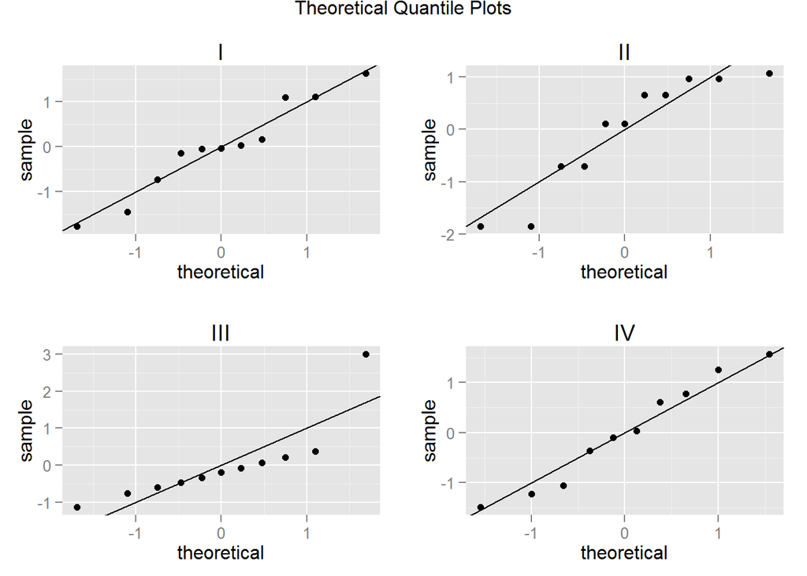

```r
qqdat1 <- ggplot(fit1, aes(sample=.stdresid))+stat_qq()+geom_abline()+ggtitle("I")
qqdat2 <- ggplot(fit2, aes(sample=.stdresid))+stat_qq()+geom_abline()+ggtitle("II")
qqdat3 <- ggplot(fit3, aes(sample=.stdresid))+stat_qq()+geom_abline()+ggtitle("III")
qqdat4 <- ggplot(fit4, aes(sample=.stdresid))+stat_qq()+geom_abline()+ggtitle("IV")

suppressWarnings(
  suppressMessages(
    grid.arrange(qqdat1, qqdat2, qqdat3, qqdat4,
                 ncol=2, main = "Theoretical Quantile Plots")))
```

**Influence Measures** Influence Measures gives several measures of influence for each observation (Cook’s Distance, et) and actually flags observations that it determines are influential by any of the measure. Generally any value over 1 indicates that observation has significant influence.

```r
influence.measures(Ilm)
```

```
## Influence measures of
##   lm(formula = y ~ x, data = Idf) :
##
##      dfb.1_     dfb.x   dffit cov.r   cook.d    hat inf
## 1   0.00033  3.15e-03  0.0104 1.406 6.14e-05 0.1000
## 2  -0.00818  4.11e-03 -0.0136 1.406 1.04e-04 0.1000
## 3   0.61888 -9.08e-01 -1.1578 0.698 4.89e-01 0.2364
## 4   0.11812 -1.14e-17  0.3563 1.037 6.16e-02 0.0909
## 5   0.01197 -2.85e-02 -0.0534 1.443 1.60e-03 0.1273
## 6   0.01618 -2.21e-02 -0.0261 1.856 3.83e-04 0.3182   *
## 7   0.45415 -3.51e-01  0.5104 1.145 1.27e-01 0.1727
## 8  -0.46907  4.07e-01 -0.4813 1.646 1.23e-01 0.3182
## 9  -0.34342  5.78e-01  0.8400 0.756 2.79e-01 0.1727
## 10 -0.46987  3.20e-01 -0.5990 0.848 1.54e-01 0.1273
## 11  0.08250 -6.84e-02  0.0872 1.647 4.27e-03 0.2364
```

```r
influence.measures(IIlm)
```

```
## Influence measures of
##   lm(formula = y ~ x, data = IIdf) :
##
##     dfb.1_     dfb.x   dffit cov.r  cook.d    hat inf
## 1   0.0102  9.72e-02  0.3223 1.127 0.05233 0.1000
## 2   0.1936 -9.72e-02  0.3223 1.127 0.05233 0.1000
## 3   0.2030 -2.98e-01 -0.3798 1.480 0.07666 0.2364
## 4   0.1139 -1.13e-17  0.3436 1.057 0.05787 0.0909
## 5  -0.0543  1.30e-01  0.2423 1.315 0.03145 0.1273
## 6   0.9475 -1.29e+00 -1.5278 0.703 0.80787 0.3182   *
## 7   0.0440 -3.40e-02  0.0495 1.525 0.00137 0.1727
## 8  -1.4889  1.29e+00 -1.5278 0.703 0.80787 0.3182   *
## 9  -0.0202  3.40e-02  0.0495 1.525 0.00137 0.1727
## 10  0.1901 -1.30e-01  0.2423 1.315 0.03145 0.1273
## 11 -0.3591  2.98e-01 -0.3798 1.480 0.07666 0.2364
```

```r
influence.measures(IIIlm)
```

```
## Influence measures of
##   lm(formula = y ~ x, data = IIIdf) :
##
##       dfb.1_     dfb.x    dffit    cov.r   cook.d    hat inf
## 1  -4.63e-03 -4.41e-02  -0.1464 1.34e+00 0.011765 0.1000
## 2  -3.71e-02  1.86e-02  -0.0618 1.39e+00 0.002141 0.1000
## 3  -3.58e+02  5.25e+02 669.5875 5.06e-11 1.392849 0.2364   *
## 4  -3.29e-02 -2.66e-18  -0.0992 1.36e+00 0.005473 0.0909
## 5   4.92e-02 -1.17e-01  -0.2193 1.34e+00 0.025984 0.1273
## 6   4.90e-01 -6.67e-01  -0.7897 1.36e+00 0.300571 0.3182
## 7   2.70e-02 -2.09e-02   0.0303 1.53e+00 0.000518 0.1727
## 8   2.41e-01 -2.09e-01   0.2472 1.80e+00 0.033817 0.3182   *
## 9   1.37e-01 -2.31e-01  -0.3362 1.34e+00 0.059536 0.1727
## 10 -1.97e-02  1.34e-02  -0.0251 1.45e+00 0.000355 0.1273
## 11  1.05e-01 -8.74e-02   0.1114 1.64e+00 0.006948 0.2364
```

```r
influence.measures(IVlm)
```

```
## Influence measures of
##   lm(formula = y ~ x, data = IVdf) :
##
##      dfb.1_    dfb.x   dffit cov.r   cook.d hat inf
## 1  -0.06827  0.03428 -0.1137 1.366 7.17e-03 0.1
## 2  -0.21353  0.10721 -0.3556 1.078 6.23e-02 0.1
## 3   0.11654 -0.05851  0.1941 1.294 2.03e-02 0.1
## 4   0.34734 -0.17439  0.5784 0.742 1.37e-01 0.1
## 5   0.26029 -0.13069  0.4334 0.958 8.72e-02 0.1
## 6   0.00628 -0.00315  0.0105 1.406 6.15e-05 0.1
## 7  -0.32505  0.16320 -0.5413 0.795 1.24e-01 0.1
## 8   0.00000  0.00000     NaN   NaN      NaN 1.0   *
## 9  -0.25432  0.12769 -0.4235 0.974 8.39e-02 0.1
## 10  0.15149 -0.07606  0.2523 1.225 3.34e-02 0.1
## 11 -0.01788  0.00898 -0.0298 1.403 4.98e-04 0.1
```

**Durbin-Watson Tests** Durbin-Watson tests for auto-correlation within the data by comparing sequential residuals of a model. A result will be between 0 and 4, with 2 indicating no auto-correlation, and values substantially different from 2 indicate that there may be cause for concern.

```r
library(lmtest)
dwtest(Ilm)
```

```
##
##  Durbin-Watson test
##
## data:  Ilm
## DW = 3.212, p-value = 0.988
## alternative hypothesis: true autocorrelation is greater than 0
```

```r
dwtest(IIlm)
```

```
##
##  Durbin-Watson test
##
## data:  IIlm
## DW = 2.188, p-value = 0.6299
## alternative hypothesis: true autocorrelation is greater than 0
```

```r
dwtest(IIIlm)
```

```
##
##  Durbin-Watson test
##
## data:  IIIlm
## DW = 2.144, p-value = 0.6016
## alternative hypothesis: true autocorrelation is greater than 0
```

```r
dwtest(IVlm)
```

```
##
##  Durbin-Watson test
##
## data:  IVlm
## DW = 1.662, p-value = 0.2892
## alternative hypothesis: true autocorrelation is greater than 0
```

**Alternate Models** Evaluating two models assuming the data sets are somehow related

##### 1. Combine all x and y data points into single data set

```r
obs <- length(cuny9$x1)  # get number of obs. for each data set
#create vector  that indicates the data source for the x and y values
dataset <- as.vector(c(rep("I",obs),rep("II",obs), rep("III",obs), rep("IV",obs)))
cunyy <- as.vector(c(cuny9$y1, cuny9$y2, cuny9$y3, cuny9$y4))  #combine all y's
cunyx <- as.vector(c(cuny9$x1, cuny9$x2, cuny9$x3, cuny9$x4))  #combine all x's
#Create data frame
cunyxy <- data.frame(cunyx, cunyy, dataset)
```

plot all 4 sets together

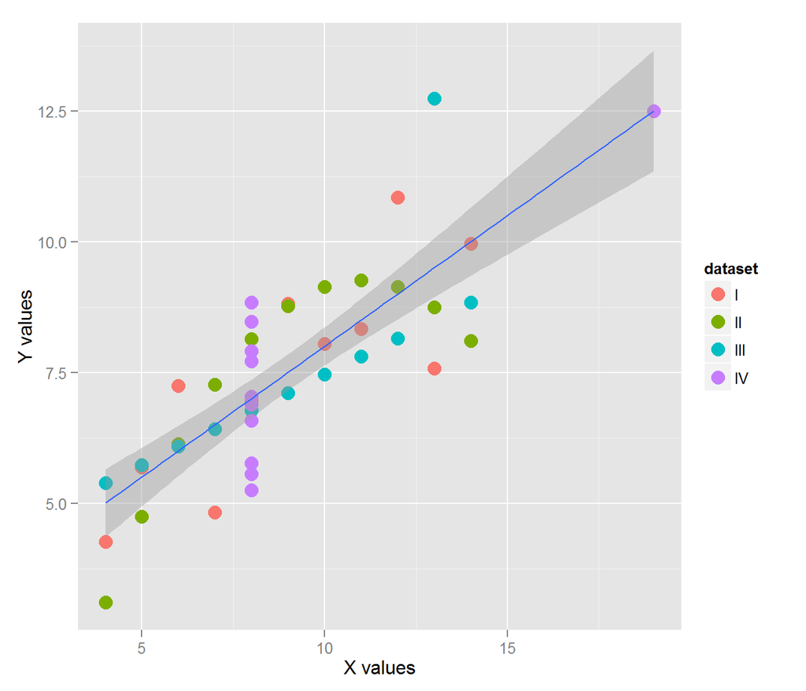

```r
e <- ggplot(data = cunyxy, aes(x=cunyx, y= cunyy))
e + geom_point(aes(color = dataset), size = 4)+geom_smooth(method = lm)+ labs(x="X values", y = "Y values")
```

# model summary

```r
lm4 <- lm(cunyx ~ cunyy,data = cunyxy)
summary(lm4)
```

```
##
## Call:
## lm(formula = cunyx ~ cunyy, data = cunyxy)
##
## Residuals:
##    Min     1Q Median     3Q    Max
## -2.984 -1.552 -0.293  1.384  4.201
##
## Coefficients:
##             Estimate Std. Error t value Pr(>|t|)
## (Intercept)   -0.999      1.127   -0.89     0.38
## cunyy          1.333      0.146    9.16  1.4e-11 ***
## ---
## Signif. codes:  0 '***' 0.001 '**' 0.01 '*' 0.05 '.' 0.1 ' ' 1
##
## Residual standard error: 1.87 on 42 degrees of freedom
## Multiple R-squared:  0.666,  Adjusted R-squared:  0.659
## F-statistic: 83.9 on 1 and 42 DF,  p-value: 1.44e-11
```

##### 2. Multivariate with y1, y2, y3 as predictors of x

```r
# combine data sets, sum of y as predictors of x value
cunyy <- as.vector(cuny9$y1 + cuny9$y2 + cuny9$y3) #adding y's for I, II, and III
cunyx <- as.vector(cuny9$x1)  #x1 = x2 = x3 = x
cunyxy <- data.frame(cunyx,cunyy)
```

# graph model

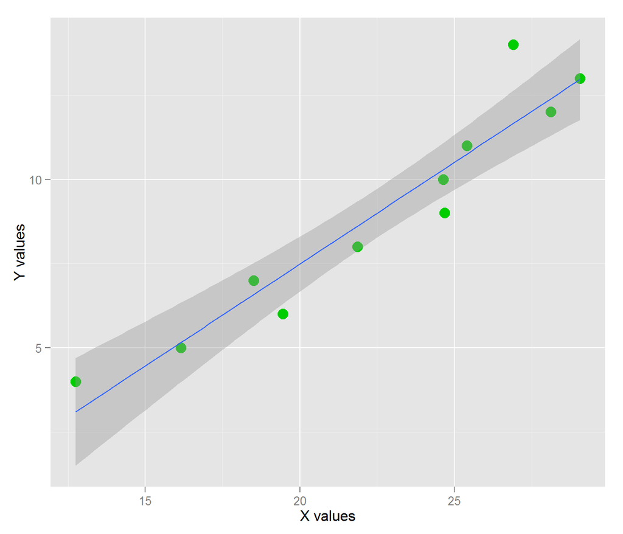

```r
e <- ggplot(data = cunyxy, aes(y =cunyx, x=cunyy))
e + geom_point(size = 4, color ="green3")+stat_smooth(method = lm)+labs(x="X values", y = "Y values")
```

# model summary on graphic model

```r
#fit on graph, indicates the sum or model of x = b1y1+b2y2+b3y3 where b1=b2=b3=1 is signficant

lm3 <- lm(cunyx ~ cunyy, data = cunyxy)
summary(lm3)
```

```
##
## Call:
## lm(formula = cunyx ~ cunyy, data = cunyxy)
##
## Residuals:
##    Min     1Q Median     3Q    Max
## -1.323 -0.504 -0.160  0.334  2.341
##
## Coefficients:
##             Estimate Std. Error t value Pr(>|t|)
## (Intercept)  -4.6053     1.4888   -3.09    0.013 *
## cunyy         0.6046     0.0646    9.36  6.2e-06 ***
## ---
## Signif. codes:  0 '***' 0.001 '**' 0.01 '*' 0.05 '.' 0.1 ' ' 1
##
## Residual standard error: 1.07 on 9 degrees of freedom
## Multiple R-squared:  0.907,  Adjusted R-squared:  0.896
## F-statistic: 87.6 on 1 and 9 DF,  p-value: 6.19e-06
```

Exploring fits for each predictor

```r
#P value on y4 and y2 indicate they may not be signficant predictors of x in a linear model
fit4 <- lm(cunyx ~ cuny9$y1 + cuny9$y2 +cuny9$y3+cuny9$y4)
summary(fit4)
```

```
##
## Call:
## lm(formula = cunyx ~ cuny9$y1 + cuny9$y2 + cuny9$y3 + cuny9$y4)
##
## Residuals:
##     Min      1Q  Median      3Q     Max
## -1.4010 -0.4953 -0.0254  0.2184  1.9327
##
## Coefficients:
##             Estimate Std. Error t value Pr(>|t|)
## (Intercept)   -6.641      2.833   -2.34    0.058 .
## cuny9$y1       0.762      0.277    2.75    0.033 *
## cuny9$y2       0.384      0.304    1.26    0.253
## cuny9$y3       0.776      0.224    3.46    0.013 *
## cuny9$y4       0.164      0.212    0.77    0.468
## ---
## Signif. codes:  0 '***' 0.001 '**' 0.01 '*' 0.05 '.' 0.1 ' ' 1
##
## Residual standard error: 1.14 on 6 degrees of freedom
## Multiple R-squared:  0.929,  Adjusted R-squared:  0.882
## F-statistic: 19.6 on 4 and 6 DF,  p-value: 0.00136
```

```r
# P value on y2 indicates it may not be a signficant predictor of x in a linear model
fit3 <- lm(cunyx ~ cuny9$y1 + cuny9$y2 +cuny9$y3)
summary(fit3)
```

```
##
## Call:
## lm(formula = cunyx ~ cuny9$y1 + cuny9$y2 + cuny9$y3)
##
## Residuals:
##    Min     1Q Median     3Q    Max
## -1.221 -0.563 -0.224  0.513  1.973
##
## Coefficients:
##             Estimate Std. Error t value Pr(>|t|)
## (Intercept)   -4.832      1.558   -3.10   0.0173 *
## cuny9$y1       0.711      0.261    2.72   0.0297 *
## cuny9$y2       0.324      0.285    1.14   0.2935
## cuny9$y3       0.810      0.214    3.79   0.0068 **
## ---
## Signif. codes:  0 '***' 0.001 '**' 0.01 '*' 0.05 '.' 0.1 ' ' 1
##
## Residual standard error: 1.11 on 7 degrees of freedom
## Multiple R-squared:  0.922,  Adjusted R-squared:  0.888
## F-statistic: 27.5 on 3 and 7 DF,  p-value: 3e-04
```

```r
#fit model excluding y2 and y4
fit2 <- lm(cunyx ~ cuny9$y1 +cuny9$y3)
summary(fit2)
```

```
##
## Call:
## lm(formula = cunyx ~ cuny9$y1 + cuny9$y3)
##
## Residuals:
##    Min     1Q Median     3Q    Max
## -1.474 -0.784 -0.143  0.757  1.552
##
## Coefficients:
##             Estimate Std. Error t value Pr(>|t|)
## (Intercept)   -4.616      1.574   -2.93   0.0189 *
## cuny9$y1       0.908      0.199    4.57   0.0018 **
## cuny9$y3       0.908      0.199    4.57   0.0018 **
## ---
## Signif. codes:  0 '***' 0.001 '**' 0.01 '*' 0.05 '.' 0.1 ' ' 1
##
## Residual standard error: 1.13 on 8 degrees of freedom
## Multiple R-squared:  0.908,  Adjusted R-squared:  0.884
## F-statistic: 39.2 on 2 and 8 DF,  p-value: 7.32e-05
```